## IS7036 Supervised Learning

*Anukriti Sharma*, *Pranav Naphad*, *Sayiram Akuthota*, *Mahesh Reddy*, *Amar Hadagali*

### Data Mining for Business Intelligence Supervised Learning Assignment

### Introduction

Goal of the Project : To study what factor and how they would impact the landing distance of a commercial flight which will eventually reduce the risk of landing overrun.

Data Used: Landing data (landing distance and other parameters) from 800 commercial flights (not real data set but simulated from statistical models).

#### Data

**Variable Dictionary**:  
1. *Aircraft*: The make of an aircraft (Boeing or Airbus).  
2. *Duration* (in minutes): Flight duration between taking off and landing. The duration of a normal flight should always be greater than 40min.  
3. *No_pasg*: The number of passengers in a flight.  
4. *Speed_ground* (in miles per hour): The ground speed of an aircraft when passing over the threshold of the runway. If its value is less than 30MPH or greater than 140MPH, then the landing would be considered as abnormal.  
5. *Speed_air* (in miles per hour): The air speed of an aircraft when passing over the threshold of the runway. If its value is less than 30MPH or greater than 140MPH, then the landing would be considered as abnormal.  
6. *Height* (in meters): The height of an aircraft when it is passing over the threshold of the runway. The landing aircraft is required to be at least 6 meters high at the threshold of the runway.  
7. *Pitch* (in degrees): Pitch angle of an aircraft when it is passing over the threshold of the runway.  
8. *Distance* (in feet): The landing distance of an aircraft. More specifically, it refers to the distance between the threshold of the runway and the point where the aircraft can be fully stopped. The length of the airport runway is typically less than 6000 feet.  
9. Packages Required

[figure not shown]

#### Import and Explore Data

**Packages**

```r
library(tidyr)
library(DT)
library(ggplot2)
library(gridExtra)
library(grid)
library(dplyr)
library(tidyverse)
library(readxl)
library(car)
library(MASS)
library(Hmisc)
library(data.table)
library(DT)
library(ROCR)
library(GGally)
library(DataExplorer)
```

*Initial Data Exploration*  
The data set was imported into R studio using the below code.

```r
faa1 <- read_excel("FAA1.xlsx")
```

*Checking the structure of data set*  
Before we begin exploring the data, we use str() function to see the structure and dimensions of the dataset.

#### Cleaning the Data

```r
str(faa1)
```

```
## tibble [800 x 8] (S3: tbl_df/tbl/data.frame)
##  $ aircraft    : chr [1:800] "boeing" "boeing" "boeing" "boeing" ...
##  $ duration    : num [1:800] 98.5 125.7 112 196.8 90.1 ...
##  $ no_pasg     : num [1:800] 53 69 61 56 70 55 54 57 61 56 ...
##  $ speed_ground: num [1:800] 107.9 101.7 71.1 85.8 59.9 ...
##  $ speed_air   : num [1:800] 109 103 NA NA NA ...
##  $ height      : num [1:800] 27.4 27.8 18.6 30.7 32.4 ...
##  $ pitch       : num [1:800] 4.04 4.12 4.43 3.88 4.03 ...
##  $ distance    : num [1:800] 3370 2988 1145 1664 1050 ...
```

**Observations:**  
The data set has 800 rows and 8 columns.

*Removing duplicates*  
We use the below command to remove the duplicates

```r
duprecords <- duplicated(faa1[,-2])
faa_new <- faa1[!duprecords,]

(faa_new)
```

```
## # A tibble: 800 x 8
##    aircraft duration no_pasg speed_ground speed_air height pitch distance
##    <chr>       <dbl>   <dbl>        <dbl>     <dbl>  <dbl> <dbl>    <dbl>
##  1 boeing       98.5      53        108.       109.   27.4  4.04    3370.
##  2 boeing      126.       69        102.       103.   27.8  4.12    2988.
##  3 boeing      112.       61         71.1       NA    18.6  4.43    1145.
##  4 boeing      197.       56         85.8       NA    30.7  3.88    1664.
##  5 boeing       90.1      70         59.9       NA    32.4  4.03    1050.
##  6 boeing      138.       55         75.0       NA    41.2  4.20    1627.
##  7 boeing       73.0      54         54.4       NA    24.0  3.84     805.
##  8 boeing       52.9      57         57.1       NA    19.4  4.64     574.
##  9 boeing      156.       61         85.4       NA    35.4  4.23    1699.
## 10 boeing      177.       56         61.8       NA    36.7  4.18    1138.
## # ... with 790 more rows
```

```r
glimpse(faa_new)
```

```
## Rows: 800
## Columns: 8
## $ aircraft     <chr> "boeing", "boeing", "boeing", "boeing", "boeing", "boeing~
## $ duration     <dbl> 98.47909, 125.73330, 112.01700, 196.82569, 90.09538, 137.~
## $ no_pasg      <dbl> 53, 69, 61, 56, 70, 55, 54, 57, 61, 56, 61, 54, 54, 58, 6~
## $ speed_ground <dbl> 107.91568, 101.65559, 71.05196, 85.81333, 59.88853, 75.01~
## $ speed_air    <dbl> 109.32838, 102.85141, NA, NA, NA, NA, NA, NA, NA, NA, NA,~
## $ height       <dbl> 27.41892, 27.80472, 18.58939, 30.74460, 32.39769, 41.2149~
## $ pitch        <dbl> 4.043515, 4.117432, 4.434043, 3.884236, 4.026096, 4.20385~
## $ distance     <dbl> 3369.8364, 2987.8039, 1144.9224, 1664.2182, 1050.2645, 16~
```

**Observation:** • The resulting data set has 800 rows and 8 columns which means that there were no duplicates in the dataset.

#### Filtering out abnormal observations

The criteria for normal and abnormal values is listed in the variable description of the data. We need to determine if there are any abnormal values or outliers as they can bias our analysis

```r
faa_new <- faa_new %>% filter(height >= 6 | is.na(height), distance < 6000 | is.na(distance), speed_air < 140 | is.na(speed_air), speed_ground > 30 | is.na(speed_ground), speed_ground < 140 | is.na(speed_ground), duration > 40 | is.na(duration))
```

```r
dim(faa_new)
```

```
## [1] 781   8
```

```r
str(faa_new)
```

```
## tibble [781 x 8] (S3: tbl_df/tbl/data.frame)
##  $ aircraft    : chr [1:781] "boeing" "boeing" "boeing" "boeing" ...
##  $ duration    : num [1:781] 98.5 125.7 112 196.8 90.1 ...
##  $ no_pasg     : num [1:781] 53 69 61 56 70 55 54 57 61 56 ...
##  $ speed_ground: num [1:781] 107.9 101.7 71.1 85.8 59.9 ...
##  $ speed_air   : num [1:781] 109 103 NA NA NA ...
##  $ height      : num [1:781] 27.4 27.8 18.6 30.7 32.4 ...
##  $ pitch       : num [1:781] 4.04 4.12 4.43 3.88 4.03 ...
##  $ distance    : num [1:781] 3370 2988 1145 1664 1050 ...
```

**Observation:**  
The number of outliers is just 19 which is not too high thus we can remove them from the data set that we want to work on.  
A total of 781 observations remain after removing outliers.

#### Variable ‘Risky Landing’

*Create the new binary variable ‘**Risky Landing**’*

The aim of our study is to develop a logistic regression model to predict if the aircraft would overshoot the runway or not. To develop a logistic model, we will create a new binary variable ‘risk landing’, using the ‘Distance’ column. It’s value would be 0 or 1 based on whether the landing distance is normal or abnormal. We also changed the data type of aircraft from character to factor.

```r
faa_new$aircraft <- as.factor(faa_new$aircraft)

faa_new$risky_landing <- ifelse(faa_new$distance > 3000,1,0)
```

```r
str(faa_new)
```

```
## tibble [781 x 9] (S3: tbl_df/tbl/data.frame)
##  $ aircraft     : Factor w/ 2 levels "airbus","boeing": 2 2 2 2 2 2 2 2 2 2 ...
##  $ duration     : num [1:781] 98.5 125.7 112 196.8 90.1 ...
##  $ no_pasg      : num [1:781] 53 69 61 56 70 55 54 57 61 56 ...
##  $ speed_ground : num [1:781] 107.9 101.7 71.1 85.8 59.9 ...
##  $ speed_air    : num [1:781] 109 103 NA NA NA ...
##  $ height       : num [1:781] 27.4 27.8 18.6 30.7 32.4 ...
##  $ pitch        : num [1:781] 4.04 4.12 4.43 3.88 4.03 ...
##  $ distance     : num [1:781] 3370 2988 1145 1664 1050 ...
##  $ risky_landing: num [1:781] 1 0 0 0 0 0 0 0 0 0 ...
```

```r
summary(faa_new)
```

```
##    aircraft      duration         no_pasg       speed_ground
##  airbus:394   Min.   : 41.95   Min.   :29.00   Min.   : 33.57
##  boeing:387   1st Qu.:119.63   1st Qu.:55.00   1st Qu.: 66.19
##               Median :154.28   Median :60.00   Median : 79.79
##               Mean   :154.78   Mean   :60.08   Mean   : 79.64
##               3rd Qu.:189.66   3rd Qu.:65.00   3rd Qu.: 92.13
##               Max.   :305.62   Max.   :87.00   Max.   :132.78
##
##    speed_air          height           pitch          distance
##  Min.   : 90.00   Min.   : 6.228   Min.   :2.284   Min.   :  41.72
##  1st Qu.: 96.15   1st Qu.:23.594   1st Qu.:3.653   1st Qu.: 919.05
##  Median :100.89   Median :30.217   Median :4.014   Median :1273.66
##  Mean   :103.50   Mean   :30.455   Mean   :4.014   Mean   :1541.20
##  3rd Qu.:109.42   3rd Qu.:36.988   3rd Qu.:4.382   3rd Qu.:1960.43
##  Max.   :132.91   Max.   :59.946   Max.   :5.927   Max.   :5381.96
##  NA's   :586
##  risky_landing
##  Min.   :0.00000
##  1st Qu.:0.00000
##  Median :0.00000
##  Mean   :0.07682
##  3rd Qu.:0.00000
##  Max.   :1.00000
##
```

```r
glimpse(faa_new)
```

```
## Rows: 781
## Columns: 9
## $ aircraft      <fct> boeing, boeing, boeing, boeing, boeing, boeing, boeing, ~
## $ duration      <dbl> 98.47909, 125.73330, 112.01700, 196.82569, 90.09538, 137~
## $ no_pasg       <dbl> 53, 69, 61, 56, 70, 55, 54, 57, 61, 56, 61, 54, 58, 63, ~
## $ speed_ground  <dbl> 107.91568, 101.65559, 71.05196, 85.81333, 59.88853, 75.0~
## $ speed_air     <dbl> 109.32838, 102.85141, NA, NA, NA, NA, NA, NA, NA, NA, NA~
## $ height        <dbl> 27.41892, 27.80472, 18.58939, 30.74460, 32.39769, 41.214~
## $ pitch         <dbl> 4.043515, 4.117432, 4.434043, 3.884236, 4.026096, 4.2038~
## $ distance      <dbl> 3369.8364, 2987.8039, 1144.9224, 1664.2182, 1050.2645, 1~
## $ risky_landing <dbl> 1, 0, 0, 0, 0, 0, 0, 0, 0, 0, 0, 0, 0, 0, 0, 0, 0, 1, 1,~
```

**Observation:**  
After adding the column, the structure and the summary of the final dataset shows that the resulting dataset has 781 observations and 9 columns.

**Correlation Coefficient**  
Next we will use the ggpairs function to create a correlation matrix to assess correlation between different variables.

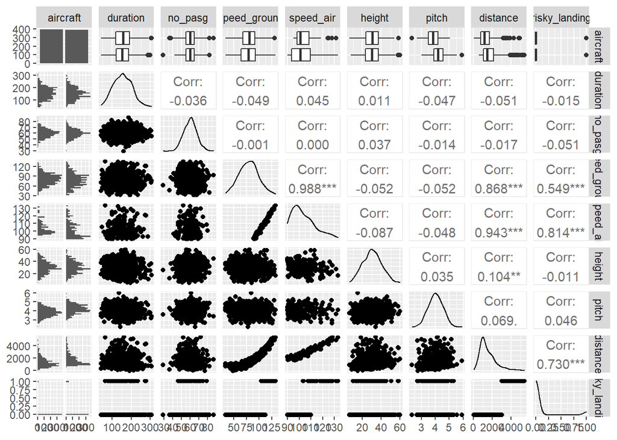

```r
ggpairs(faa_new)
```

**Observations:***  
• High co-relation between speed air and distance (0.943).  
• High correlation between speed ground and distance (0.868).  
• High co-relation between speed air and speed ground (0.988).

### Data Splitting

Before building the model, we will split the data set into training and testing data, keeping the training dataset as 70 percent of the total data.

```r
set.seed(123456)

index <- sample (nrow (faa_new),nrow(faa_new)*0.70)
faa_train = faa_new[index,]
faa_test = faa_new[-index,]
```

```r
names(faa_train)
```

```
## [1] "aircraft"      "duration"      "no_pasg"       "speed_ground"
## [5] "speed_air"     "height"        "pitch"         "distance"
## [9] "risky_landing"
```

```r
str(faa_train)
```

```
## tibble [546 x 9] (S3: tbl_df/tbl/data.frame)
##  $ aircraft     : Factor w/ 2 levels "airbus","boeing": 2 2 2 2 1 2 2 2 1 2 ...
##  $ duration     : num [1:546] 154 260 80 194 155 ...
##  $ no_pasg      : num [1:546] 63 46 64 51 59 57 57 67 64 60 ...
##  $ speed_ground : num [1:546] 94.6 91.7 100.2 84.8 61.5 ...
##  $ speed_air    : num [1:546] 93.9 93.1 100.3 NA NA ...
##  $ height       : num [1:546] 41.4 44.6 48.6 23.3 24.8 ...
##  $ pitch        : num [1:546] 4.76 3.69 5.06 4.96 3.83 ...
##  $ distance     : num [1:546] 2343 2483 2771 1770 617 ...
##  $ risky_landing: num [1:546] 0 0 0 0 0 0 0 0 0 0 ...
```

```r
glimpse(faa_train)
```

```
## Rows: 546
## Columns: 9
## $ aircraft      <fct> boeing, boeing, boeing, boeing, airbus, boeing, boeing, ~
## $ duration      <dbl> 154.06174, 260.03402, 79.99931, 193.99574, 155.02208, 91~
## $ no_pasg       <dbl> 63, 46, 64, 51, 59, 57, 57, 67, 64, 60, 61, 63, 48, 67, ~
## $ speed_ground  <dbl> 94.63081, 91.65670, 100.17254, 84.84092, 61.46172, 62.63~
## $ speed_air     <dbl> 93.93528, 93.05483, 100.26067, NA, NA, NA, 92.91770, NA,~
## $ height        <dbl> 41.42338, 44.60146, 48.60282, 23.30227, 24.81810, 33.410~
## $ pitch         <dbl> 4.757853, 3.692308, 5.055818, 4.956640, 3.833905, 4.5781~
## $ distance      <dbl> 2342.7732, 2482.6563, 2771.1313, 1769.7810, 617.0306, 10~
## $ risky_landing <dbl> 0, 0, 0, 0, 0, 0, 0, 0, 0, 0, 0, 0, 1, 0, 0, 0, 0, 0, 0,~
```

**Distribution of Risky_Landing**  
Next we use a bar plot to see the frequency of abnormal landings within our dataset.

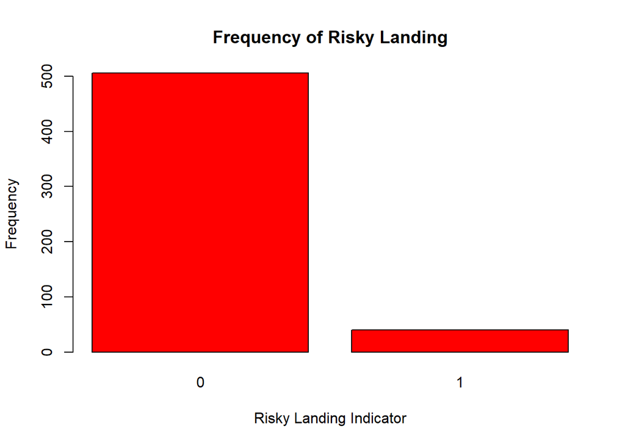

```r
barplot(table(faa_train$risky_landing), xlab = "Risky Landing Indicator", ylab = "Frequency", main = "Frequency of Risky Landing", col = "Red")
```

**Observations:**  
From the plot, we can conclude that very few flights have risky landing distance.

### Analysis:Risky Landing

**Risky Landing Analysis**  
*Single Factor Regression Analysis for Risky Landing*

```r
FAA_final = mutate(faa_train, aircraft_num = ifelse(aircraft == "airbus", 1, 0))
varnames <- names(FAA_final)
df <- FAA_final[, which(!names(FAA_final) %in% c("aircraft_num"))]
varnames <- names(df)
signif_table <- data.frame(variable_name = character(), regression_coefficient = numeric(), odds_ratio = numeric(), pvalue = numeric(), coefficient_direction = character(), stringsAsFactors = FALSE)
```

```r
i = 1
for (var in varnames[!varnames %in% c("risky_landing")]) {
  Y <- df$risky_landing
  X <- unlist(df[, var])
  reg <- glm(Y ~ X, family = binomial)
  signif_table[i, 1] = var
  signif_table[i, 2] = abs(summary(reg)$coefficients[2, 1])
  signif_table[i, 3] = exp(summary(reg)$coefficients[2, 1])
  signif_table[i, 4] = summary(reg)$coefficients[2, 4]
  signif_table[i, 5] = ifelse(summary(reg)$coefficients[2, 1] > 0, "Positive", "Negative")
  i = i + 1
}
```

```r
signif_table <- signif_table %>% arrange(pvalue)

signif_table
```

```
##   variable_name regression_coefficient odds_ratio       pvalue
## 1  speed_ground            0.668095992  1.9505200 3.686871e-05
## 2     speed_air            1.571288128  4.8128438 3.743007e-03
## 3      aircraft            0.926390403  2.5253771 9.318817e-03
## 4       no_pasg            0.023394445  0.9768771 2.706624e-01
## 5      duration            0.002205128  0.9977973 5.177941e-01
## 6         pitch            0.155534197  1.1682819 6.260482e-01
## 7        height            0.003585744  0.9964207 8.289027e-01
## 8      distance            0.413982378  1.5128305 9.860971e-01
##   coefficient_direction
## 1              Positive
## 2              Positive
## 3              Positive
## 4              Negative
## 5              Negative
## 6              Positive
## 7              Negative
## 8              Positive
```

**Observation:**  
The variables which can be considered significant for our model analysis (p-value < 0.05) are:  
• Speed_ground  
• Speed_air  
• aircraft

Next we standardize the variables and then perform single factor regression analysis and we get the same results.

```r
df <- FAA_final[, which(!names(FAA_final) %in% c("aircraft_num"))]
varnames <- names(df)
StdCoeff_table <- data.frame(variable_name = character(), regression_coefficient = numeric(), odds_ratio = numeric(), pvalue = numeric(), coefficient_direction = character(), stringsAsFactors = FALSE)
```

```r
i = 1
for (var in varnames[!varnames %in% c("risky_landing")]) {
  Y <- df$risky_landing
  X <- if (var == "aircraft") {
    unlist(df[, var])
    } else {
    unlist(scale(df[, var]))
    }
  reg <- glm(Y ~ X, family = binomial)
  signif_table[i, 1] = var
  signif_table[i, 2] = abs(summary(reg)$coefficients[2, 1])
  signif_table[i, 3] = exp(summary(reg)$coefficients[2, 1])
  signif_table[i, 4] = summary(reg)$coefficients[2, 4]
  signif_table[i, 5] = ifelse(summary(reg)$coefficients[2, 1] > 0, "Positive", "Negative")
  i = i + 1
}
```

```r
signif_table <- signif_table %>% arrange(pvalue)
signif_table
```

```
##   variable_name regression_coefficient    odds_ratio       pvalue
## 1  speed_ground            12.59138492  2.940147e+05 3.686871e-05
## 2     speed_air            15.25648103  4.224794e+06 3.743007e-03
## 3      aircraft             0.92639040  2.525377e+00 9.318817e-03
## 4       no_pasg             0.17985801  8.353888e-01 2.706624e-01
## 5      duration             0.10760789  8.979796e-01 5.177941e-01
## 6         pitch             0.08030785  1.083621e+00 6.260482e-01
## 7        height             0.03560043  9.650258e-01 8.289027e-01
## 8      distance           369.39549786 2.669478e+160 9.860971e-01
##   coefficient_direction
## 1              Positive
## 2              Positive
## 3              Positive
## 4              Negative
## 5              Negative
## 6              Positive
## 7              Negative
## 8              Positive
```

From the above table, we can conclude that the variables which can be considered significant for our model analysis(p-value < 0.05) are:  
• Speed_ground  
• Speed_air  
• aircraft

**Visualizing the signifcant Factors using Scatter Plot**

We plot scatter plots of risky_landing vs all the other significant variables, to visualize the significance of the variables on risky_landing

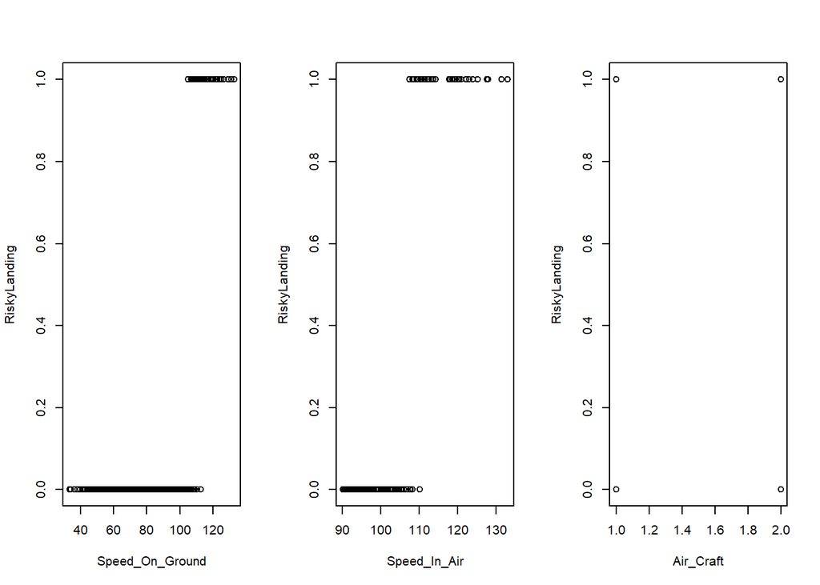

```r
par(mfrow = c(1,3))
RiskyLanding <- FAA_final$risky_landing
Speed_On_Ground <- FAA_final$speed_ground
Speed_In_Air <- FAA_final$speed_air
Air_Craft <- as.numeric(FAA_final$aircraft)

plot(Speed_On_Ground,RiskyLanding)

plot(Speed_In_Air,RiskyLanding)

plot(Air_Craft,RiskyLanding)
```

### Full Model

*Final Full Model for Risky Landing*  
Now we build a Final Full Model for Risky Landing.  
We only choose **speed_ground** and **aircraft** as the predictor variables.  
We remove duration, no_pasg and pitch as they are not significant based on the above analysis.  
We also remove speed_air as it is highly correlated with speed_ground and has a lot of missing values.

```r
final_model_risky_landing <- glm(risky_landing ~ speed_ground + aircraft, data = FAA_final, family = binomial)

summary(final_model_risky_landing)
```

```
##
## Call:
## glm(formula = risky_landing ~ speed_ground + aircraft, family = binomial,
##     data = FAA_final)
##
## Deviance Residuals:
##      Min        1Q    Median        3Q       Max
## -2.27546  -0.00004   0.00000   0.00000   1.92849
##
## Coefficients:
##                Estimate Std. Error z value Pr(>|z|)
## (Intercept)    -112.583     34.812  -3.234  0.00122 **
## speed_ground      1.020      0.315   3.238  0.00120 **
## aircraftboeing    3.720      1.523   2.443  0.01458 *
## ---
## Signif. codes:  0 '***' 0.001 '**' 0.01 '*' 0.05 '.' 0.1 ' ' 1
##
## (Dispersion parameter for binomial family taken to be 1)
##
##     Null deviance: 286.09  on 545  degrees of freedom
## Residual deviance:  27.54  on 543  degrees of freedom
## AIC: 33.54
##
## Number of Fisher Scoring iterations: 12
```

AIC and BIC Analysis for Risky Landing  
Next we try to analyze the AIC and BIC values for our model.

**AIC**

```r
null_model_risky_landing <- glm(risky_landing~1, data = FAA_final, family = binomial)
```

```r
full_model_risky_landing <- glm(risky_landing~aircraft + duration + no_pasg + speed_ground + height + pitch, data = FAA_final, family = binomial)
```

```r
model_aic_risky_landing <- step(null_model_risky_landing, scope = list(lower = null_model_risky_landing, upper = full_model_risky_landing), direction = 'both')
```

```
## Start:  AIC=288.09
## risky_landing ~ 1
##
##                Df Deviance     AIC
## + speed_ground  1   37.972  41.972
## + aircraft      1  278.750 282.750
## <none>             286.094 288.094
## + no_pasg       1  284.886 288.886
## + duration      1  285.673 289.673
## + pitch         1  285.857 289.857
## + height        1  286.048 290.048
##
## Step:  AIC=41.97
## risky_landing ~ speed_ground
##
##                Df Deviance     AIC
## + pitch         1   24.912  30.912
## + aircraft      1   27.540  33.540
## + duration      1   35.245  41.245
## <none>              37.972  41.972
## + no_pasg       1   37.927  43.927
## + height        1   37.948  43.948
## - speed_ground  1  286.094 288.094
##
## Step:  AIC=30.91
## risky_landing ~ speed_ground + pitch
##
##                Df Deviance     AIC
## <none>              24.912  30.912
## + aircraft      1   23.338  31.338
## + duration      1   24.505  32.505
## + no_pasg       1   24.758  32.758
## + height        1   24.768  32.768
## - pitch         1   37.972  41.972
## - speed_ground  1  285.857 289.857
```

```r
summary(model_aic_risky_landing)
```

```
##
## Call:
## glm(formula = risky_landing ~ speed_ground + pitch, family = binomial,
##     data = FAA_final)
##
## Deviance Residuals:
##      Min        1Q    Median        3Q       Max
## -3.06943  -0.00004   0.00000   0.00000   1.46859
##
## Coefficients:
##               Estimate Std. Error z value Pr(>|z|)
## (Intercept)  -124.4437    35.4150  -3.514 0.000442 ***
## speed_ground    1.0347     0.2977   3.476 0.000509 ***
## pitch           3.0761     1.0903   2.821 0.004781 **
## ---
## Signif. codes:  0 '***' 0.001 '**' 0.01 '*' 0.05 '.' 0.1 ' ' 1
##
## (Dispersion parameter for binomial family taken to be 1)
##
##     Null deviance: 286.094  on 545  degrees of freedom
## Residual deviance:  24.912  on 543  degrees of freedom
## AIC: 30.912
##
## Number of Fisher Scoring iterations: 12
```

```r
model_bic_risky_landing <- step(null_model_risky_landing, scope = list(lower = null_model_risky_landing, upper = full_model_risky_landing), direction = 'both', k = log(nrow(FAA_final)))
```

```
## Start:  AIC=292.4
## risky_landing ~ 1
##
##                Df Deviance     AIC
## + speed_ground  1   37.972  50.577
## + aircraft      1  278.750 291.356
## <none>             286.094 292.397
## + no_pasg       1  284.886 297.491
## + duration      1  285.673 298.278
## + pitch         1  285.857 298.462
## + height        1  286.048 298.653
##
## Step:  AIC=50.58
## risky_landing ~ speed_ground
##
##                Df Deviance     AIC
## + pitch         1   24.912  43.820
## + aircraft      1   27.540  46.448
## <none>              37.972  50.577
## + duration      1   35.245  54.153
## + no_pasg       1   37.927  56.835
## + height        1   37.948  56.855
## - speed_ground  1  286.094 292.397
##
## Step:  AIC=43.82
## risky_landing ~ speed_ground + pitch
##
##                Df Deviance     AIC
## <none>              24.912  43.820
## + aircraft      1   23.338  48.548
## + duration      1   24.505  49.715
## + no_pasg       1   24.758  49.969
## + height        1   24.768  49.979
## - pitch         1   37.972  50.577
## - speed_ground  1  285.857 298.462
```

```r
summary(model_bic_risky_landing)
```

```
##
## Call:
## glm(formula = risky_landing ~ speed_ground + pitch, family = binomial,
##     data = FAA_final)
##
## Deviance Residuals:
##      Min        1Q    Median        3Q       Max
## -3.06943  -0.00004   0.00000   0.00000   1.46859
##
## Coefficients:
##               Estimate Std. Error z value Pr(>|z|)
## (Intercept)  -124.4437    35.4150  -3.514 0.000442 ***
## speed_ground    1.0347     0.2977   3.476 0.000509 ***
## pitch           3.0761     1.0903   2.821 0.004781 **
## ---
## Signif. codes:  0 '***' 0.001 '**' 0.01 '*' 0.05 '.' 0.1 ' ' 1
##
## (Dispersion parameter for binomial family taken to be 1)
##
##     Null deviance: 286.094  on 545  degrees of freedom
## Residual deviance:  24.912  on 543  degrees of freedom
## AIC: 30.912
##
## Number of Fisher Scoring iterations: 12
```

Final Analysis and Results for Risky Landing  
• We have developed a model based on significant p-values, and minimum BIC. The covariates are speed_ground and pitch .  
• Below is a table with model characteristics:

```r
datatable(data.frame("Coefficients" = summary(model_bic_risky_landing)$coefficients[2:3,1], "Odds" = exp(summary(model_bic_risky_landing)$coefficients[2:3,1]) ))
```

|  | Coefficients | Odds |
| --- | --- | --- |
| speed_ground | 1.03472993547759 | 2.81434607795345 |
| pitch | 3.0760763581678 | 21.6731974844421 |

**Observation:** • The model has the following characteristics: AIC: 30.91 BIC: 43.82  
• The risky landing can be expressed as a linear function of the above two parameters.  
• Keeping other factors constant, a unit increase in speed ground increases the odds of risky landing by 2.814.  
• Keeping other factors constant, a unit increase in pitch increases the odds of risky landing by 21.673.

### Model Selection

Since BIC is more conservative, we are Selecting the **BIC Model**.

```r
summary_model <- summary(model_bic_risky_landing)

summary_model
```

```
##
## Call:
## glm(formula = risky_landing ~ speed_ground + pitch, family = binomial,
##     data = FAA_final)
##
## Deviance Residuals:
##      Min        1Q    Median        3Q       Max
## -3.06943  -0.00004   0.00000   0.00000   1.46859
##
## Coefficients:
##               Estimate Std. Error z value Pr(>|z|)
## (Intercept)  -124.4437    35.4150  -3.514 0.000442 ***
## speed_ground    1.0347     0.2977   3.476 0.000509 ***
## pitch           3.0761     1.0903   2.821 0.004781 **
## ---
## Signif. codes:  0 '***' 0.001 '**' 0.01 '*' 0.05 '.' 0.1 ' ' 1
##
## (Dispersion parameter for binomial family taken to be 1)
##
##     Null deviance: 286.094  on 545  degrees of freedom
## Residual deviance:  24.912  on 543  degrees of freedom
## AIC: 30.912
##
## Number of Fisher Scoring iterations: 12
```

```r
model_bic_risky_landing$deviance
```

```
## [1] 24.91242
```

```r
AIC(model_bic_risky_landing)
```

```
## [1] 30.91242
```

```r
BIC(model_bic_risky_landing)
```

```
## [1] 43.82028
```

In-Sample Prediction

Next we proceed with in sample prediction and to give an overall measure of goodness of classification, we will use the ‘Receiver Operating Characteristic (ROC) curve’.

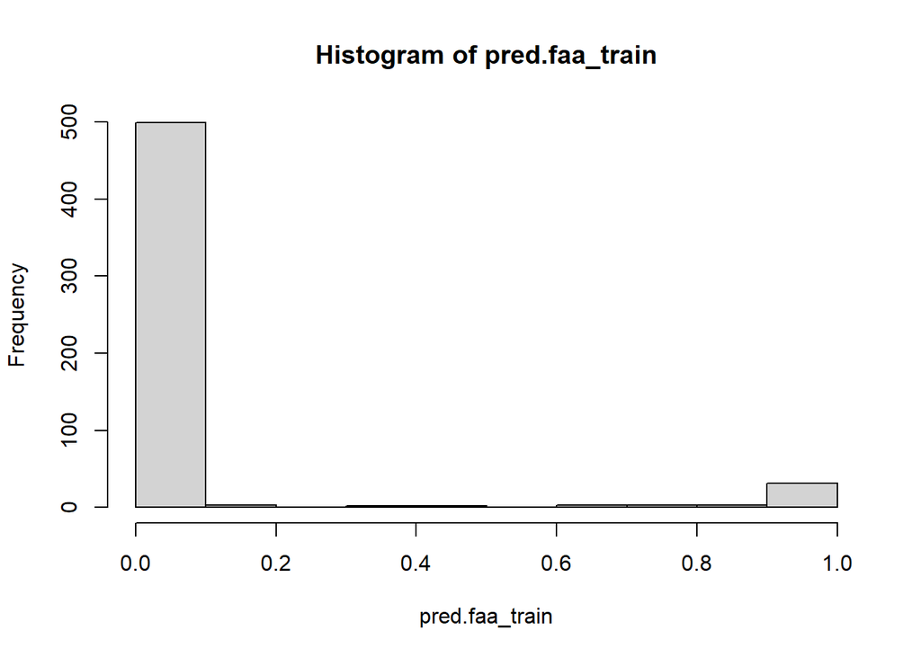

```r
pred.faa_train <- predict(model_bic_risky_landing, type="response")

hist(pred.faa_train)
```

```r
table(predict(model_bic_risky_landing, type="response") > 0.07)
```

```
##
## FALSE  TRUE
##   496    50
```

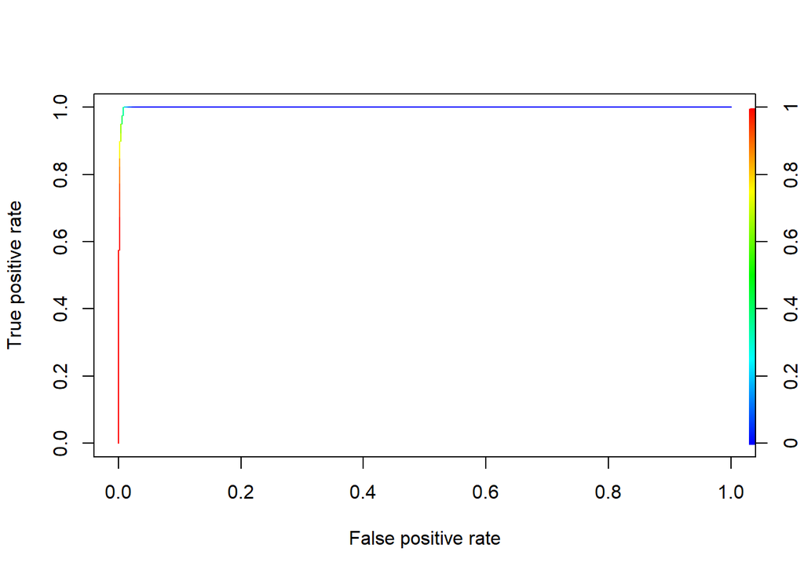

```r
library(ROCR)
pred <- prediction(pred.faa_train, FAA_final$risky_landing)
perf <- performance(pred, "tpr", "fpr")
plot(perf, colorize=TRUE)
```

```r
unlist(slot(performance(pred, "auc"), "y.values"))
```

```
## [1] 0.9988142
```

**Observation**  
Area under Curve value is **0.998**

*Precision-Recall Curve*  
Precision and recall curve and its AUC is more appropriate for imbalanced data. We use package PRROC to draw the PR curve as well as the ROC curve.

```r
library(PRROC)
score1= pred.faa_train[FAA_final$risky_landing==1]
score0= pred.faa_train[FAA_final$risky_landing==0]
roc= roc.curve(score1, score0, curve = T)
roc$auc
```

```
## [1] 0.9988142
```

```r
pr= pr.curve(score1, score0, curve = T)
pr
```

```
##
##   Precision-recall curve
##
##     Area under curve (Integral):
##      0.9825075
##
##     Area under curve (Davis & Goadrich):
##      0.9825047
##
##     Curve for scores from  2.220446e-16  to  1
##     ( can be plotted with plot(x) )
```

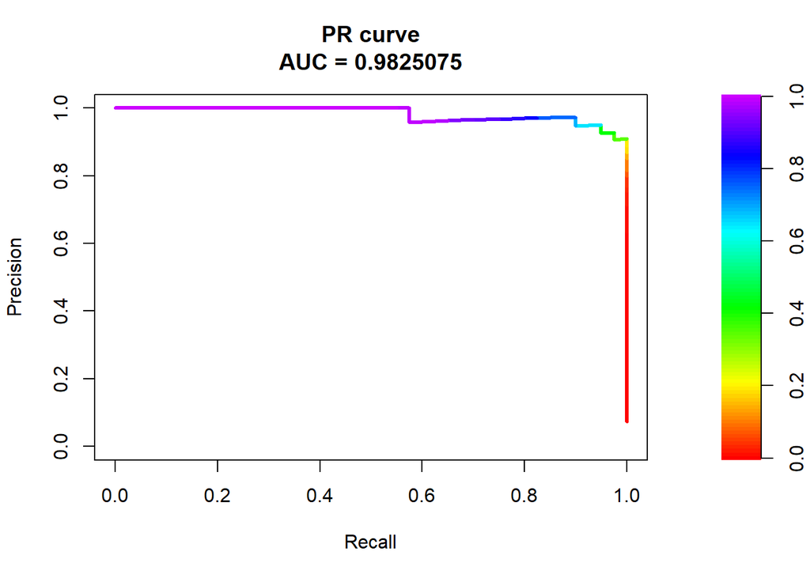

```r
plot(pr)
```

```r
pred.faa_test<- predict(model_bic_risky_landing, newdata = faa_train, type="response")
```

**ROC Curve**

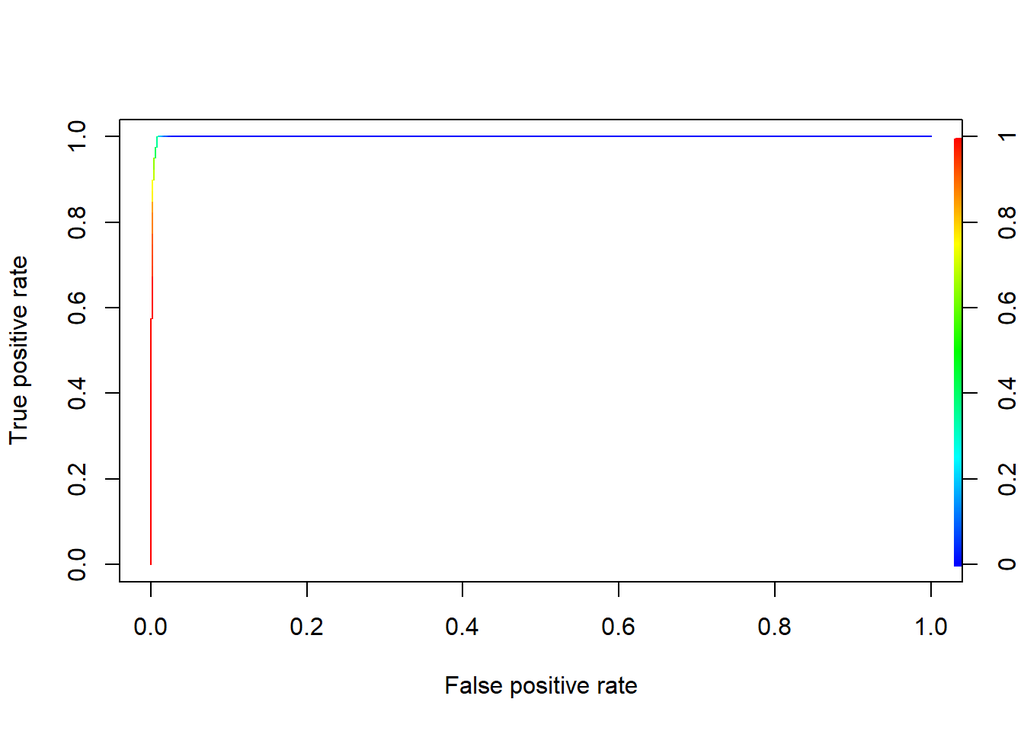

```r
pred <- prediction(pred.faa_train, faa_train$risky_landing)
perf <- performance(pred, "tpr", "fpr")
plot(perf, colorize=TRUE)
```

```r
#Get the AUC
unlist(slot(performance(pred, "auc"), "y.values"))
```

```
## [1] 0.9988142
```

*Precision-Recall Curve*

```r
score1.test= pred.faa_test[faa_train$risky_landing==1]
score0.test= pred.faa_test[faa_train$risky_landing==0]
roc.test= roc.curve(score1.test, score0.test, curve = T)
roc.test$auc
```

```
## [1] 0.9988142
```

```r
pr.test= pr.curve(score1.test, score0.test, curve = T)
pr.test
```

```
##
##   Precision-recall curve
##
##     Area under curve (Integral):
##      0.9825075
##
##     Area under curve (Davis & Goadrich):
##      0.9825047
##
##     Curve for scores from  2.220446e-16  to  1
##     ( can be plotted with plot(x) )
```

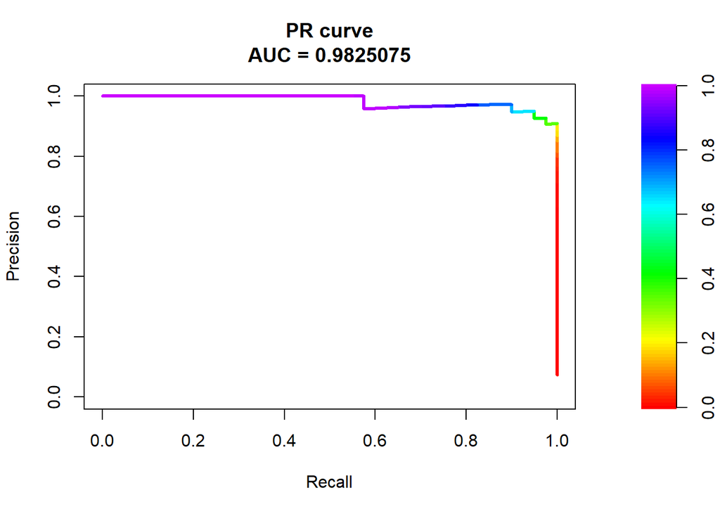

```r
plot(pr.test)
```

P - Cut  
Assuming PCut to be the mean of the response variable where it is equal to 1.

```r
pcut <- mean(FAA_final$risky_landing)
pcut
```

```
## [1] 0.07326007
```

Based on this cut-off probability, we can obtain the binary prediction (predicted classification) and the confusion matrix

```r
# get binary prediction
class.Faa_final <- (pred.faa_train>pcut)*1
# get confusion matrix
table(FAA_final$risky_landing, class.Faa_final, dnn = c("True", "Predicted"))
```

```
##     Predicted
## True   0   1
##    0 497   9
##    1   0  40
```

Commonly, you can use overall MR as the cost (a criterion) to evaluate the model prediction.

(equal-weighted) misclassification rate

```r
MR_OutSample <- mean(faa_test$risky_landing!=class.Faa_final)

MR_InSample <- mean(faa_train$risky_landing!=class.Faa_final)
```

**MR Value**

```r
MR_InSample
```

```
## [1] 0.01648352
```

```r
MR_OutSample
```

```
## [1] 0.1593407
```

**Observation**  
• In Sample Misclassification rate of the model with is **0.0164**  
• Out Sample Misclassification rate of the model with is **0.1593**

### Classification Tree

**What is Classification Tree?**  
Classification and regression trees are machine-learning methods for constructing prediction models from data.  
The models are obtained by recursively partitioning the data space and fitting a simple prediction model within each partition.  
As a result, the partitioning can be represented graphically as a decision tree.  
Classification trees are designed for dependent variables that take a finite number of unordered values, with prediction error measured in terms of misclassification cost.  
The dataset contains 800 observations and 8 variables.  
400 observations from Airbus flights and 400 from Boeing flights.

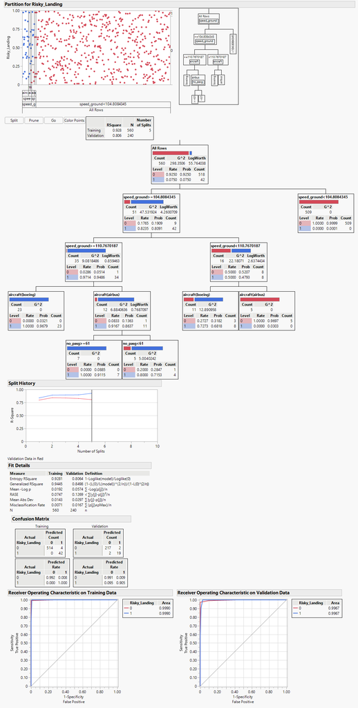

Decision_Tree

### Conclusion

The dataset we chose for out model presented quite a few challenges:  
• The recommended distance for safety landing is under 6000 feet, and our response variable has predominantly 0’s (safe landing distance) for majority of the planes, versus 1’s (risky landing). This may have caused the model to inaccurately predict the risk landing factor. We had a few disagreements as to how to address the issue, i.e. which cutoff distance to choose as a selection criterium.  
• Also, the data seems to underestimate the landing distance of the planes’ quite dramatically. For example, A380 requires at least 7800 feet for take-off/landing depending on the weather and some other conditions.  
• The other issue was the multicollinearity between the independent variables (between speed ground and distance, speed air and speed ground). One of the possible solutions, besides excluding one of the speed variables, is to create interaction terms. One of them is number of passengers divided by the ground speed, the other one is the height of the plane divided by the number of passengers.

[figure not shown]

Compare

*After comparing the above parameters, we can say the best model is Classification Tree for the prediction of landing distance being within the risky category or not.*

The Federal Aviation Administration can find this analysis valuable for designing the airports.  
There are some types of planes that need landing run way to be more than 6000 like cargo carrires etc, but for small local airports this prediction will assist the FAA architects to plan the airport.  
The similar type of analysis can also be done for other heavy planes.